# Assignment-4

# Final analysis and Extracting results using 5 clusters and Visualize the results

```r
set.seed(300)
final_Cluster<- kmeans(Pharmascale, 5, nstart = 25)
print(final_Cluster)
```

```
## K-means clustering with 5 clusters of sizes 8, 3, 4, 2, 4
##
## Cluster means:
##    Market_Cap       Beta    PE_Ratio        ROE        ROA Asset_Turnover
## 1 -0.03142211 -0.4360989 -0.31724852  0.1950459  0.4083915      0.1729746
## 2 -0.87051511  1.3409869 -0.05284434 -0.6184015 -1.1928478     -0.4612656
## 3 -0.76022489  0.2796041 -0.47742380 -0.7438022 -0.8107428     -1.2684804
## 4 -0.43925134 -0.4701800  2.70002464 -0.8349525 -0.9234951      0.2306328
## 5  1.69558112 -0.1780563 -0.19845823  1.2349879  1.3503431      1.1531640
##      Leverage Rev_Growth Net_Profit_Margin
## 1 -0.27449312 -0.7041516       0.556954446
## 2  1.36644699 -0.6912914      -1.320000179
## 3  0.06308085  1.5180158      -0.006893899
## 4 -0.14170336 -0.1168459      -1.416514761
## 5 -0.46807818  0.4671788       0.591242521
##
## Clustering vector:
##  ABT  AGN  AHM  AZN  AVE  BAY  BMY CHTT  ELN  LLY  GSK  IVX  JNJ  MRX  MRK  NVS
##    1    4    1    1    3    2    1    2    3    1    5    2    5    3    5    1
##  PFE  PHA  SGP  WPI  WYE
##    5    4    1    3    1
##
## Within cluster sum of squares by cluster:
## [1] 21.879320 15.595925 12.791257  2.803505  9.284424
##  (between_SS / total_SS =  65.4 %)
##
## Available components:
##
## [1] "cluster"      "centers"      "totss"        "withinss"     "tot.withinss"
## [6] "betweenss"    "size"         "iter"         "ifault"
```

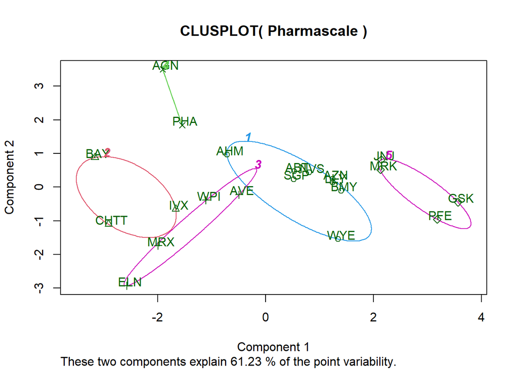

```r
clusplot(Pharmascale,final_Cluster$cluster, color = TRUE, labels = 2,lines = 0)
```

2. Interpret the clusters with respect to the numerical variables used in forming the clusters Cluster 1 - AHM,SGP,WYE,BMY,AZN, ABT, NVS, LLY Cluster 2 - BAY, CHTT, IVX Cluster 3 - WPI, MRX,ELN,AVE Cluster 4 - AGN, PHA Cluster 5 - JNJ, MRK, PFE,GSK

```r
Pharma_Cluster <- Pharmaceuticaldata[,c(12,13,14)]%>% mutate(clusters = final_Cluster$cluster)%>% arrange(clusters, ascending = TRUE)
Pharma_Cluster
```

```
##      Median_Recommendation    Location Exchange clusters
## ABT           Moderate Buy          US     NYSE        1
## AHM             Strong Buy          UK     NYSE        1
## AZN          Moderate Sell          UK     NYSE        1
## BMY          Moderate Sell          US     NYSE        1
## LLY                   Hold          US     NYSE        1
## NVS                   Hold SWITZERLAND     NYSE        1
## SGP                   Hold          US     NYSE        1
## WYE                   Hold          US     NYSE        1
## BAY                   Hold     GERMANY     NYSE        2
## CHTT          Moderate Buy          US   NASDAQ        2
## IVX                   Hold          US     AMEX        2
## AVE           Moderate Buy      FRANCE     NYSE        3
## ELN          Moderate Sell     IRELAND     NYSE        3
## MRX           Moderate Buy          US     NYSE        3
## WPI          Moderate Sell          US     NYSE        3
## AGN           Moderate Buy      CANADA     NYSE        4
## PHA                   Hold          US     NYSE        4
## GSK                   Hold          UK     NYSE        5
## JNJ           Moderate Buy          US     NYSE        5
## MRK                   Hold          US     NYSE        5
## PFE           Moderate Buy          US     NYSE        5
```

# c)Is there a pattern in the clusters with respect to the numerical variables (10 to 12)? (those not used in forming the clusters)

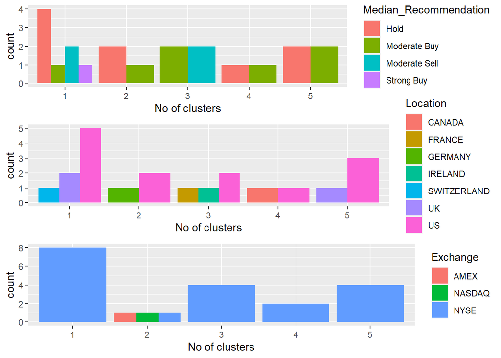

```r
plot1<-ggplot(Pharma_Cluster, mapping = aes(factor(clusters), fill=Median_Recommendation))+geom_bar(position = 'dodge')+labs(x ='No of clusters')
plot2<- ggplot(Pharma_Cluster, mapping = aes(factor(clusters),fill = Location))+geom_bar(position = 'dodge')+labs(x ='No of clusters')
plot3<- ggplot(Pharma_Cluster, mapping = aes(factor(clusters),fill = Exchange))+geom_bar(position = 'dodge')+labs(x ='No of clusters')
grid.arrange(plot1, plot2, plot3)
```

# d)Provide an appropriate name for each cluster using any or all of the variables in the dataset.

Cluster1-Hold Cluster Cluster2-Hold Cluster Cluster3-Buy-Sell Cluster Cluster4-Hold-Buy Cluster Cluster5-Hold-Buy Cluster